# GLM: Intervals & Tests

2018-05-15

## The Generalized Linear Model: GLM

- 3.0 Introduction
- 3.1 Intervals & Tests
- 3.2 Residuals & Assumptions
- 3.3 Let's practice more

## You will learn in this session

- that estimates are still roughly normally distributed (but only roughly)
- how to compute intervals for GLM
- that intervals based on likelihood are best for family with known dispersion
- that established methods don't always work well, so you should always run tests
- that parametric bootstrap can outperform other methods when done properly
- that intervals on scale other than \(\eta\) must be done by hand or using `spaMM`
- that tests from summary tables are only reliable for the gaussian family
- that LR tests are best for family with known dispersion
- that LR tests by parametric bootstrap are best in all situations and easy to do with `spaMM`

## Our data

```r
set.seed(1L)
Aliens <- simulate_Aliens_GLM()
head(Aliens)
```

```
##   humans_eaten     size eggs happy blue_eyes pink_eyes
## 1            4 57.99053    1     0         5         2
## 2            6 55.93987    0     0         5         4
## 3            9 65.20560    1     1         8         0
## 4           14 65.35318    1     0         8         0
## 5            3 61.66512    0     1         5         1
## 6           13 79.40200    5     0        11         1
```

```r
attributes(Aliens)$param.eta$size
```

```
## intercept     slope
##      50.0       1.5
```

```r
attributes(Aliens)$param.eta$blue_eyes
```

```
## intercept     slope
##      -2.0       0.5
```

## Our toy models

```r
mod_gauss <- glm(size  ~ humans_eaten, family = gaussian(), data = Aliens)
mod_poiss <- glm(eggs  ~ humans_eaten, family = poisson(),  data = Aliens)
mod_binar <- glm(happy ~ humans_eaten, family = binomial(), data = Aliens)
mod_binom <- glm(cbind(blue_eyes, pink_eyes) ~ humans_eaten, family = binomial(), data = Aliens)
```

## Uncertainty in estimates

## Covariances between parameter estimates

### gaussian family

```r
X <- model.matrix(mod_gauss)
W <- matrix(0, ncol = nrow(mod_gauss$model), nrow = nrow(mod_gauss$model))
diag(W) <- mod_gauss$weights
XTWX <- t(X) %*% W %*% X
phi <- mod_gauss$deviance / mod_gauss$df.residual
phi*solve(XTWX)
```

```
##              (Intercept) humans_eaten
## (Intercept)    1.0644762  -0.10818355
## humans_eaten  -0.1081836   0.01388749
```

```r
vcov(mod_gauss)
```

```
##              (Intercept) humans_eaten
## (Intercept)    1.0644762  -0.10818355
## humans_eaten  -0.1081836   0.01388749
```

## Covariances between parameter estimates

### gaussian family

Same using the QR decomposition:

```r
(XTWX <- crossprod(mod_gauss$R))
```

```
##              (Intercept) humans_eaten
## (Intercept)          100          779
## humans_eaten         779         7665
```

```r
phi <- mod_gauss$deviance / mod_gauss$df.residual
phi*solve(XTWX)
```

```
##              (Intercept) humans_eaten
## (Intercept)    1.0644762  -0.10818355
## humans_eaten  -0.1081836   0.01388749
```

## Covariances between parameter estimates

### Poisson family

```r
vcov(mod_poiss)
```

```
##               (Intercept)  humans_eaten
## (Intercept)   0.062526884 -0.0061174210
## humans_eaten -0.006117421  0.0007314367
```

```r
XTWX <- crossprod(mod_poiss$R)
phi <- 1
phi*solve(XTWX)
```

```
##               (Intercept)  humans_eaten
## (Intercept)   0.062526884 -0.0061174210
## humans_eaten -0.006117421  0.0007314367
```

## Covariances between parameter estimates

### Binomial family (binary case)

```r
vcov(mod_binar)
```

```
##              (Intercept) humans_eaten
## (Intercept)   0.25202409 -0.025672720
## humans_eaten -0.02567272  0.003189073
```

```r
XTWX <- crossprod(mod_binar$R)
phi <- 1
phi*solve(XTWX)
```

```
##              (Intercept) humans_eaten
## (Intercept)   0.25202409 -0.025672720
## humans_eaten -0.02567272  0.003189073
```

## Covariances between parameter estimates

### Binomial family (general case)

```r
vcov(mod_binom)
```

```
##               (Intercept) humans_eaten
## (Intercept)   0.062629612 -0.009333457
## humans_eaten -0.009333457  0.001749529
```

```r
XTWX <- crossprod(mod_binom$R)
phi <- 1
phi*solve(XTWX)
```

```
##               (Intercept) humans_eaten
## (Intercept)   0.062629612 -0.009333457
## humans_eaten -0.009333457  0.001749529
```

## Distribution of parameter estimates

The parameter estimates are asymptotically normally distributed.

```r
new_betas <- t(replicate(1000, update(mod_gauss, data = simulate_Aliens_GLM(N = 1000))$coef))
```

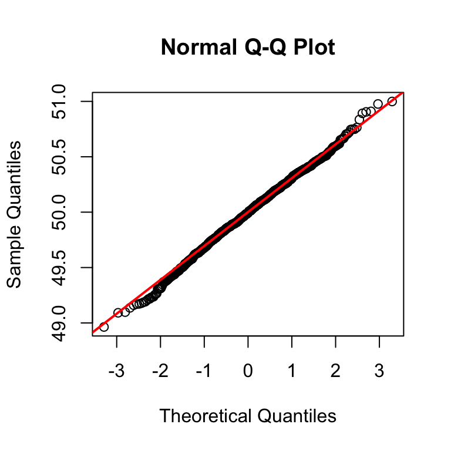

```r
qqnorm(new_betas[, 1])
qqline(new_betas[, 1], col = "red", lwd = 2)
```

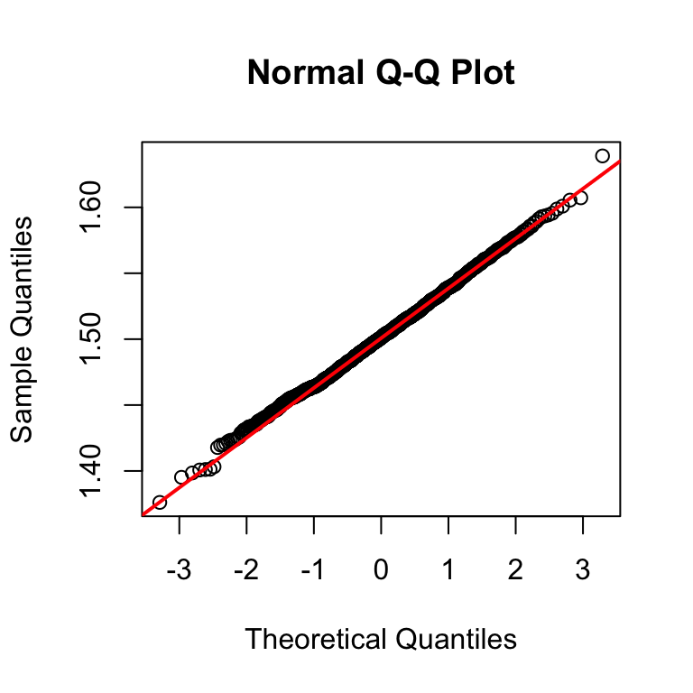

```r
qqnorm(new_betas[, 2])
qqline(new_betas[, 2], col = "red", lwd = 2)
```

## Distribution of parameter estimates

The parameter estimates are asymptotically normally distributed.

```r
new_betas <- t(replicate(1000, update(mod_gauss, data = simulate_Aliens_GLM(N = 10))$coef))
```

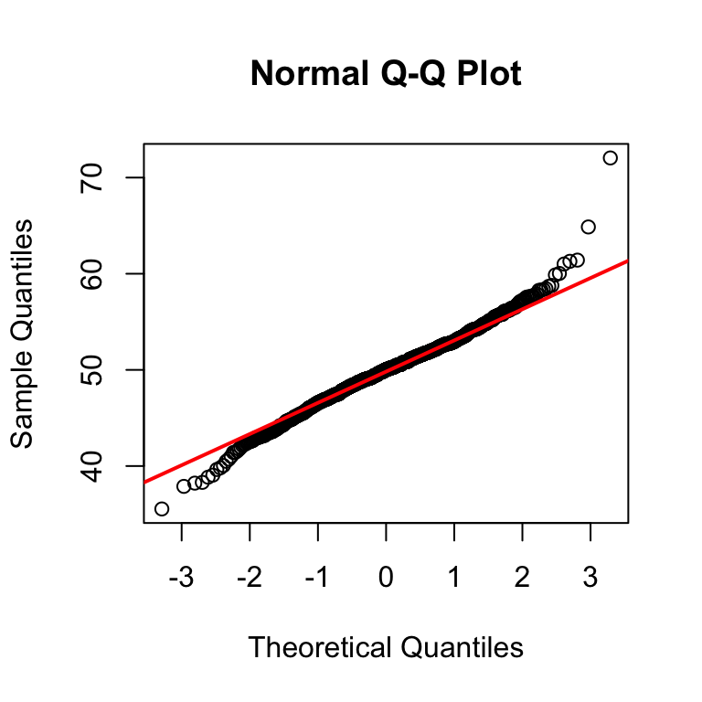

```r
qqnorm(new_betas[, 1])
qqline(new_betas[, 1], col = "red", lwd = 2)
```

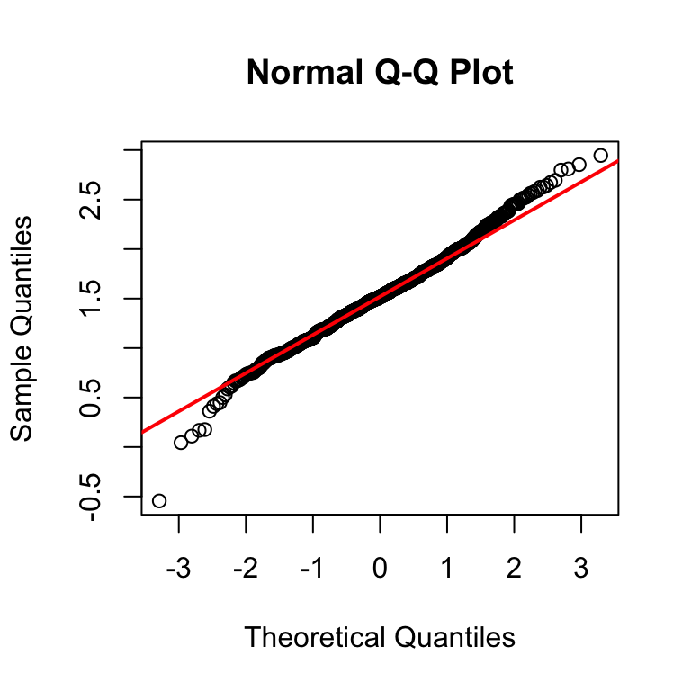

```r
qqnorm(new_betas[, 2])
qqline(new_betas[, 2], col = "red", lwd = 2)
```

## Distribution of parameter estimates

The parameter estimates are asymptotically normally distributed.

```r
new_betas <- t(replicate(1000, update(mod_poiss, data = simulate_Aliens_GLM(N = 1000))$coef))
```

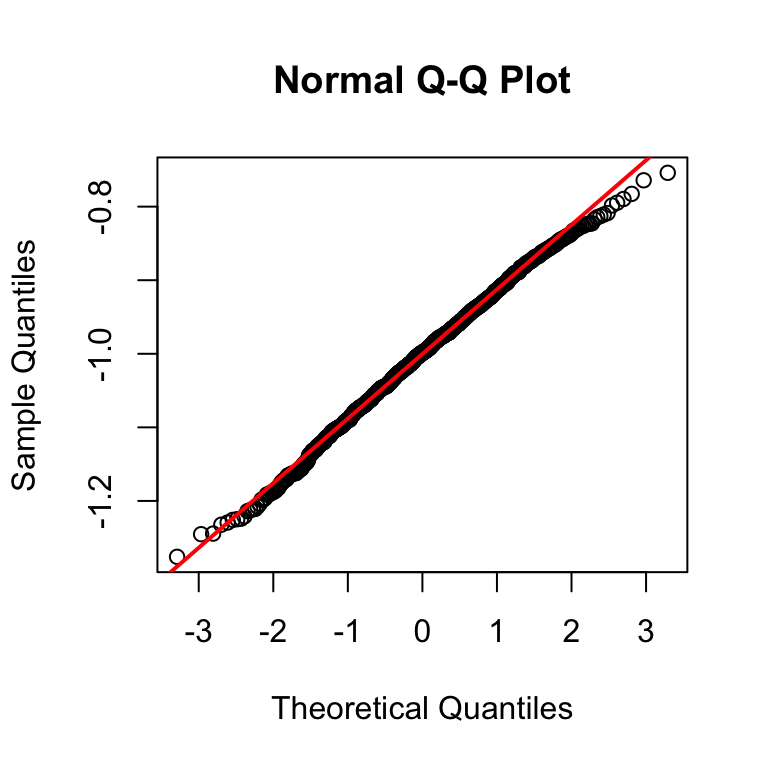

```r
qqnorm(new_betas[, 1])
qqline(new_betas[, 1], col = "red", lwd = 2)
```

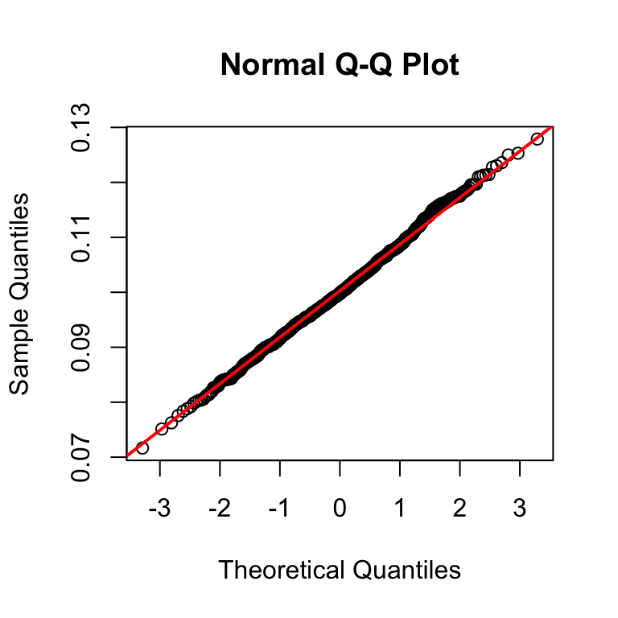

```r
qqnorm(new_betas[, 2])
qqline(new_betas[, 2], col = "red", lwd = 2)
```

## Distribution of parameter estimates

The parameter estimates are asymptotically normally distributed.

```r
new_betas <- t(replicate(1000, update(mod_poiss, data = simulate_Aliens_GLM(N = 10))$coef))
```

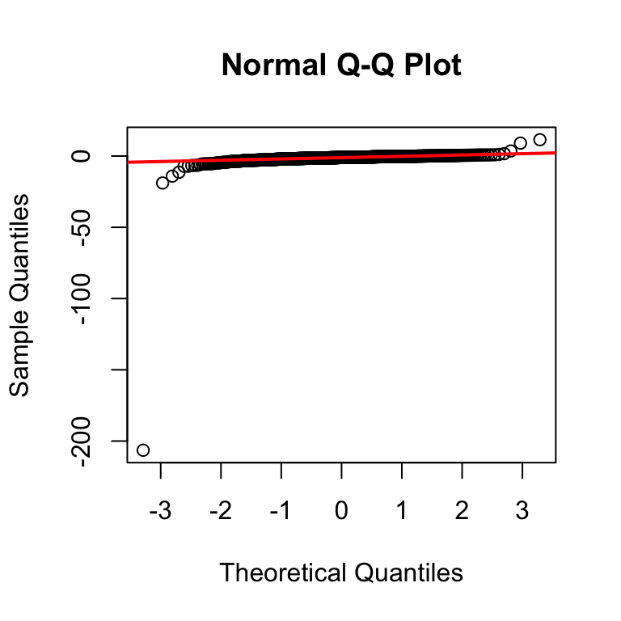

```r
qqnorm(new_betas[, 1])
qqline(new_betas[, 1], col = "red", lwd = 2)
```

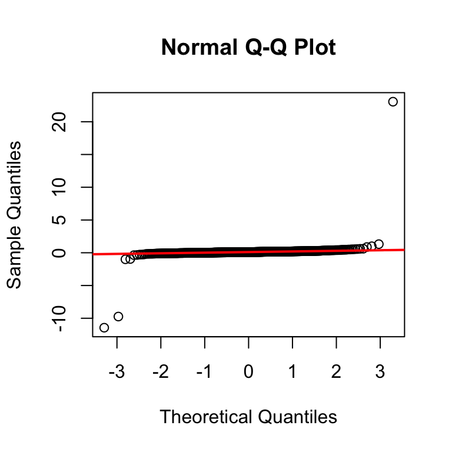

```r
qqnorm(new_betas[, 2])
qqline(new_betas[, 2], col = "red", lwd = 2)
```

## Distribution of parameter estimates

The parameter estimates are asymptotically normally distributed.

```r
new_betas <- t(replicate(1000, update(mod_binar, data = simulate_Aliens_GLM(N = 1000))$coef))
```

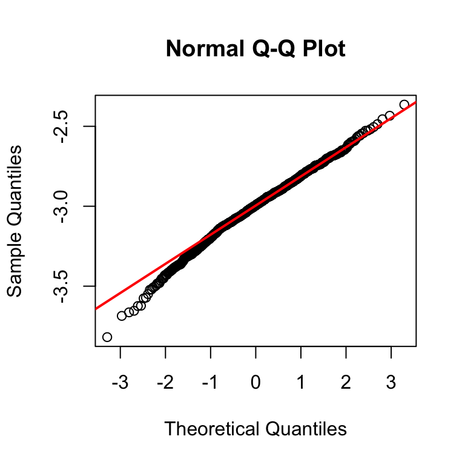

```r
qqnorm(new_betas[, 1])
qqline(new_betas[, 1], col = "red", lwd = 2)
```

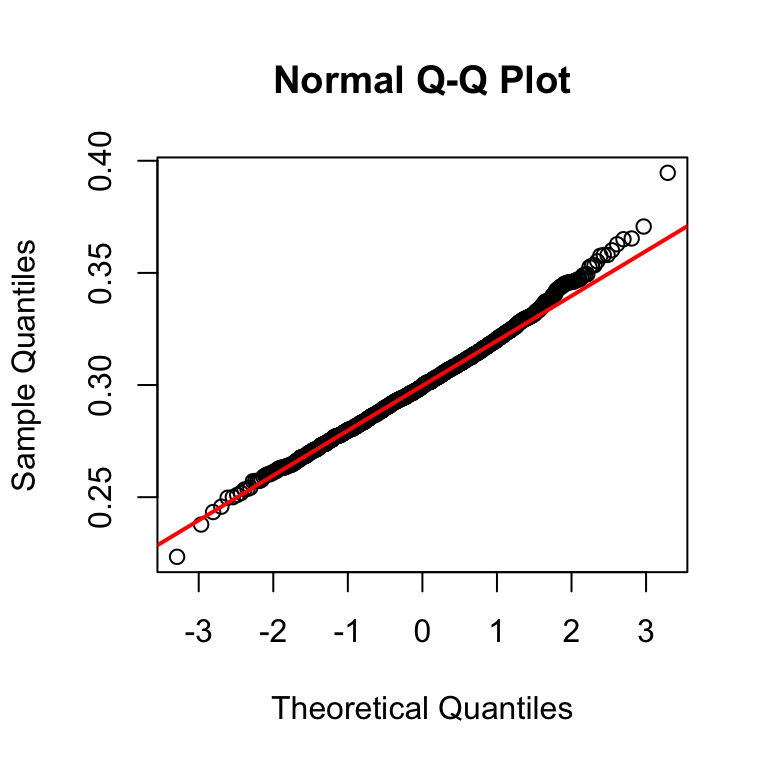

```r
qqnorm(new_betas[, 2])
qqline(new_betas[, 2], col = "red", lwd = 2)
```

## Distribution of parameter estimates

The parameter estimates are asymptotically normally distributed.

```r
new_betas <- t(replicate(1000, update(mod_binar, data = simulate_Aliens_GLM(N = 10))$coef))
```

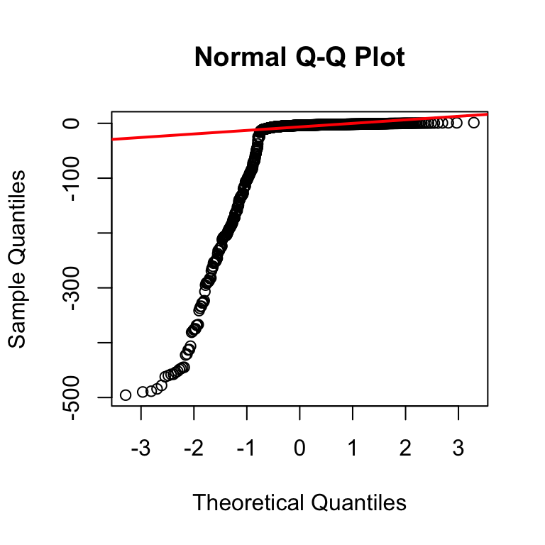

```r
qqnorm(new_betas[, 1])
qqline(new_betas[, 1], col = "red", lwd = 2)
```

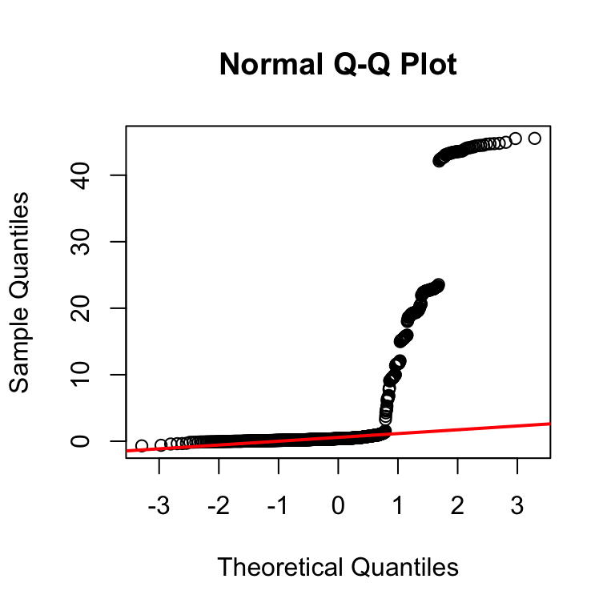

```r
qqnorm(new_betas[, 2])
qqline(new_betas[, 2], col = "red", lwd = 2)
```

## Distribution of parameter estimates

The parameter estimates are asymptotically normally distributed.

```r
new_betas <- t(replicate(1000, update(mod_binom, data = simulate_Aliens_GLM(N = 1000))$coef))
```

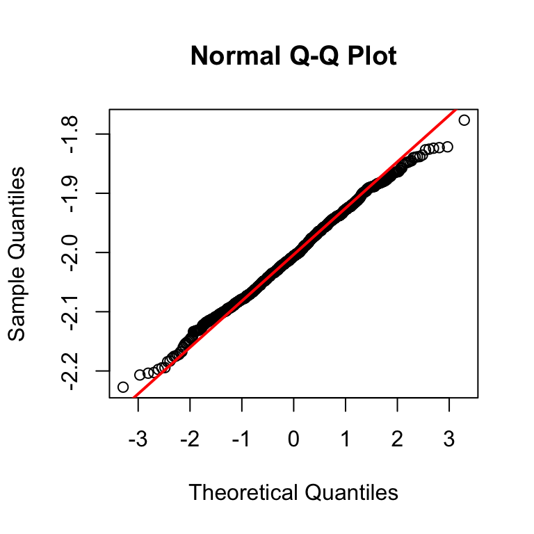

```r
qqnorm(new_betas[, 1])
qqline(new_betas[, 1], col = "red", lwd = 2)
```

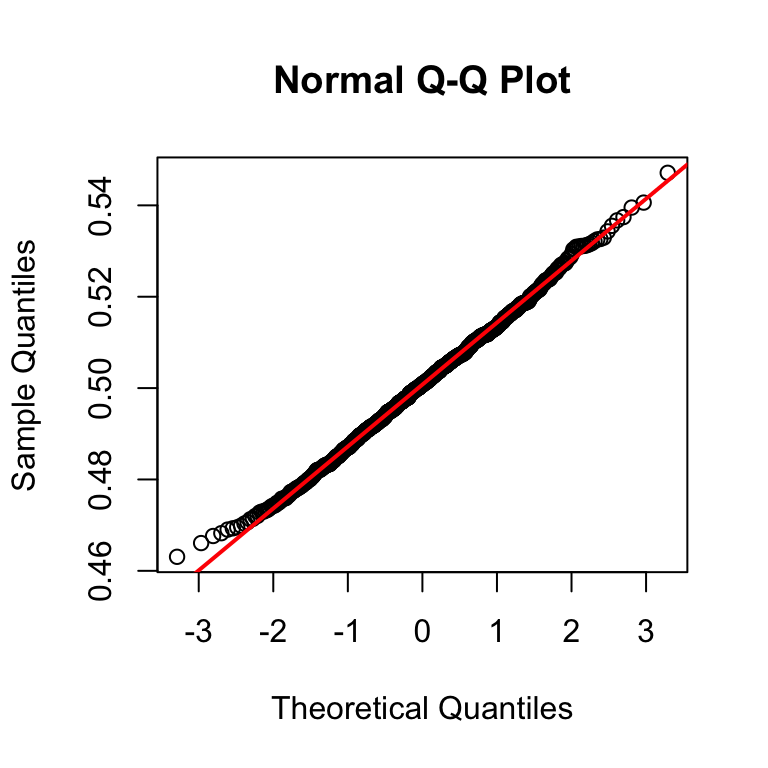

```r
qqnorm(new_betas[, 2])
qqline(new_betas[, 2], col = "red", lwd = 2)
```

## Distribution of parameter estimates

The parameter estimates are asymptotically normally distributed.

```r
new_betas <- t(replicate(1000, update(mod_binom, data = simulate_Aliens_GLM(N = 10))$coef))
```

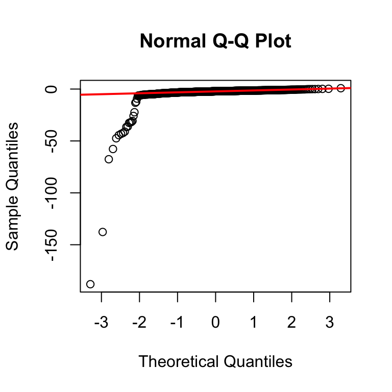

```r
qqnorm(new_betas[, 1])
qqline(new_betas[, 1], col = "red", lwd = 2)
```

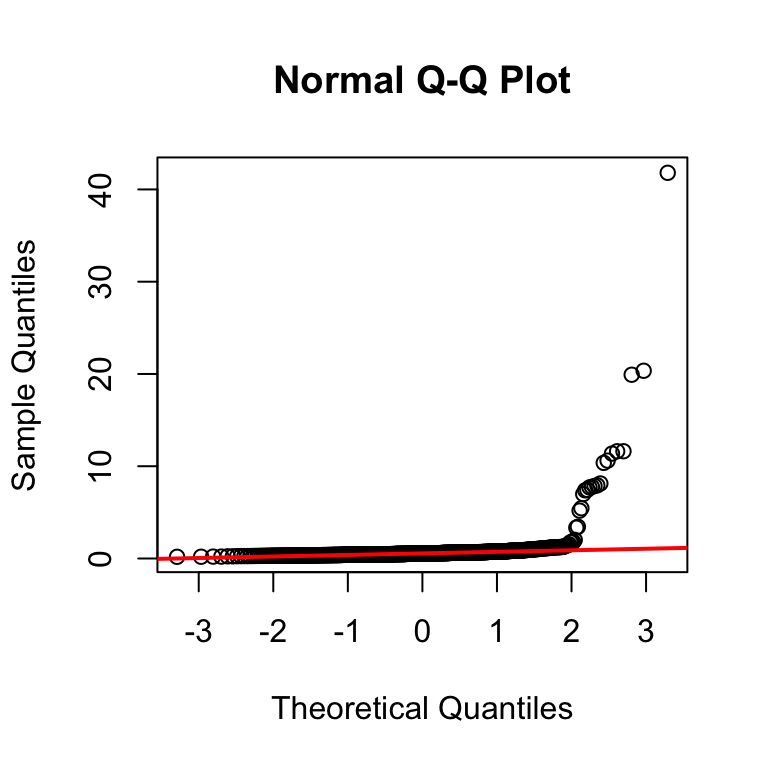

```r
qqnorm(new_betas[, 2])
qqline(new_betas[, 2], col = "red", lwd = 2)
```

## Distribution of parameter estimates

### Conclusion

- Large dataset: the assumption of normality for the distribution of parameter estimates holds well.
- Small dataset: the assumption of normality for the distribution of parameter estimates holds well for `gaussian()`, but it really does not for the other families.

### Open question

How small is small? -> Simulate as we did to check for your design.

### Challenge

Determine if the issue is steming from the link function, the family or both.

Tip: test by simulation using `gaussian(link = "log")` and `poisson(link = "identity")`.

## Confidence intervals on estimates

## CI by gaussian approximation

## 95% CI using gaussian approximation

### Computation

```r
confint.approx <- function(mod, print = FALSE) {

  intervals <- cbind(lwr = (mod$coefficients + qnorm(0.025) *  sqrt(diag(vcov(mod)))),
                     upr = (mod$coefficients + qnorm(0.975) *  sqrt(diag(vcov(mod)))))

  if (print) print(intervals)
  name.response <- mod$terms[[2]]
  if (length(name.response) == 3) name.response <- name.response[[2]]
  true.intercept <- attributes(mod$data)$param.eta[[paste(name.response)]][1]
  true.slope <- attributes(mod$data)$param.eta[[paste(name.response)]][2]
  if (print) cat("\n true parameters in 95% CI? \n")

  c(true.intercept > intervals["(Intercept)", "lwr"] & true.intercept < intervals["(Intercept)", "upr"],
    true.slope > intervals["humans_eaten", "lwr"] & true.slope < intervals["humans_eaten", "upr"])
}
```

## 95% CI using gaussian approximation

### Testing our function

```r
confint.approx(mod_poiss, print = TRUE)
```

```
##                      lwr        upr
## (Intercept)  -0.91157496 0.06861777
## humans_eaten -0.01665672 0.08935807
##
##  true parameters in 95% CI?
```

```
## intercept     slope
##     FALSE     FALSE
```

## 95% CI using gaussian approximation

### Coverage

```r
set.seed(1L)
replicate(5, confint.approx(update(mod_poiss, data = simulate_Aliens_GLM())))
```

```
##            [,1] [,2] [,3] [,4] [,5]
## intercept FALSE TRUE TRUE TRUE TRUE
## slope     FALSE TRUE TRUE TRUE TRUE
```

## 95% CI using gaussian approximation

### Coverage N = 10

```r
set.seed(3L)
test_poiss <- replicate(1000, confint.approx(update(mod_poiss, data = simulate_Aliens_GLM(N = 10))))
test_binar <- replicate(1000, confint.approx(update(mod_binar, data = simulate_Aliens_GLM(N = 10))))
test_binom <- replicate(1000, confint.approx(update(mod_binom, data = simulate_Aliens_GLM(N = 10))))
test_gauss <- replicate(1000, confint.approx(update(mod_gauss, data = simulate_Aliens_GLM(N = 10))))
rbind(poiss = apply(test_poiss, 1, mean, na.rm = TRUE),
      binar = apply(test_binar, 1, mean, na.rm = TRUE),
      binom = apply(test_binom, 1, mean, na.rm = TRUE),
      gauss = apply(test_gauss, 1, mean, na.rm = TRUE))
```

```
##       intercept slope
## poiss     0.959 0.975
## binar     0.974 0.981
## binom     0.972 0.971
## gauss     0.923 0.915
```

Bad for all!

## 95% CI using gaussian approximation

### Coverage N = 2000

```r
set.seed(1L)
test_poiss <- replicate(1000, confint.approx(update(mod_poiss, data = simulate_Aliens_GLM(N = 2000))))
test_binar <- replicate(1000, confint.approx(update(mod_binar, data = simulate_Aliens_GLM(N = 2000))))
test_binom <- replicate(1000, confint.approx(update(mod_binom, data = simulate_Aliens_GLM(N = 2000))))
test_gauss <- replicate(1000, confint.approx(update(mod_gauss, data = simulate_Aliens_GLM(N = 2000))))
rbind(poiss = apply(test_poiss, 1, mean),
      binar = apply(test_binar, 1, mean),
      binom = apply(test_binom, 1, mean),
      gauss = apply(test_gauss, 1, mean))
```

```
##       intercept slope
## poiss     0.943 0.937
## binar     0.955 0.950
## binom     0.950 0.946
## gauss     0.960 0.949
```

Good for all!

## 95% CI using gaussian approximation

### Coverage N = 100

```r
set.seed(1L)
test_poiss <- replicate(1000, confint.approx(update(mod_poiss, data = simulate_Aliens_GLM(N = 100))))
test_binar <- replicate(1000, confint.approx(update(mod_binar, data = simulate_Aliens_GLM(N = 100))))
test_binom <- replicate(1000, confint.approx(update(mod_binom, data = simulate_Aliens_GLM(N = 100))))
test_gauss <- replicate(1000, confint.approx(update(mod_gauss, data = simulate_Aliens_GLM(N = 100))))
rbind(poiss = apply(test_poiss, 1, mean),
      binar = apply(test_binar, 1, mean),
      binom = apply(test_binom, 1, mean),
      gauss = apply(test_gauss, 1, mean))
```

```
##       intercept slope
## poiss     0.952 0.943
## binar     0.949 0.953
## binom     0.957 0.949
## gauss     0.939 0.938
```

Good for all but `gaussian()` which would need to rely on the quantiles from the student distribution!

## 95% CI using gaussian approximation

### Conclusion

- Large datasets: good coverage for all families.
- Small datasets: bad coverage specifically for family for which a dispersion parameters must be estimated. This is a problem for `gaussian()` but also for other families we have not seen yet (the `quasiXXX()`).

## 95% CI on two parameters using gaussian approximation

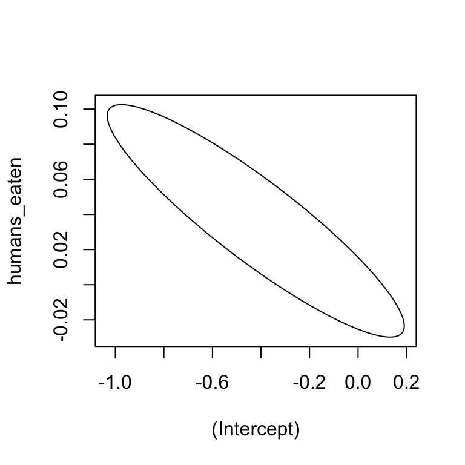

```r
library(ellipse)
el <- ellipse(mod_poiss)
plot(el, type = "l")
```

## CI by likelihood profiling

## Recall: likelihood profiling

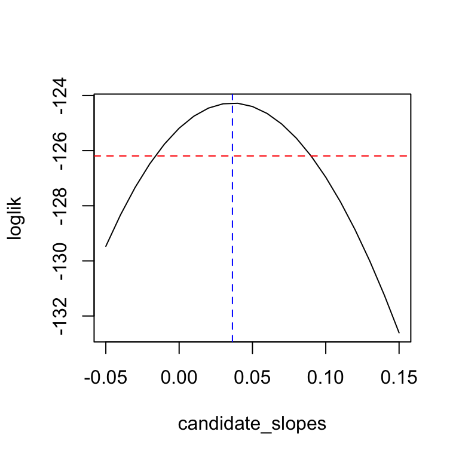

```r
loglik <- sapply(candidate_slopes <- seq(-0.05, 0.15, 0.01), function(param) {
  logLik(glm(eggs ~ 1 + offset(param*humans_eaten),
                        family = poisson(), data = mod_poiss$model))[[1]]
})
plot(loglik ~ candidate_slopes, type = "l")
abline(v = coef(mod_poiss)[2], lty = 2, col = "blue")
abline(h = logLik(mod_poiss)[[1]] - 0.5*qchisq(0.95, df = 1), lty = 2, col = "red")
```

## 95% CI by likelihood profiling

### Computation by hand

```r
where.is.limit <- function(param, which = 1) {
  if (which == 1) {
    logLik_mod <- logLik(glm(eggs ~ 0 + humans_eaten + offset(rep(param, nrow(mod_poiss$model))),
                       family = poisson(), data = mod_poiss$model))[[1]]
  } else if (which == 2) {
    logLik_mod <- logLik(glm(eggs ~ 1 + offset(param*humans_eaten),
                        family = poisson(), data = mod_poiss$model))[[1]]
  }

  logLik_goal <- logLik(mod_poiss)[[1]] - 0.5*qchisq(0.95, df = 1)
  return(abs(logLik_mod - logLik_goal))
  }
```

```r
intercept_lwr <- nlminb(start = -10, where.is.limit, which = 1)$par
intercept_upr <- nlminb(start = 10, where.is.limit, which = 1)$par
slope_lwr     <- nlminb(start = -1, where.is.limit, which = 2)$par
slope_upr     <- nlminb(start = 2, where.is.limit, which = 2)$par
rbind(c(intercept_lwr, intercept_upr), c(slope_lwr, slope_upr))
```

```
##             [,1]       [,2]
## [1,] -0.93514983 0.04691876
## [2,] -0.01626709 0.08997391
```

## 95% CI by likelihood profiling

### Computation using spaMM

```r
library(spaMM)
mod_poiss_spaMM <- fitme(eggs  ~ humans_eaten, family = poisson(),  data = Aliens)
confint(mod_poiss_spaMM, parm = 1)
```

```
## lower (Intercept) upper (Intercept)
##       -0.93514587        0.04691189
```

```r
confint(mod_poiss_spaMM, parm = 2)
```

[output not shown]

## 95% CI by likelihood profiling

### Computation using MASS

```r
library(MASS)
confint(mod_poiss)
```

```
##                    2.5 %     97.5 %
## (Intercept)  -0.93515069 0.04691548
## humans_eaten -0.01626681 0.08997519
```

## 95% CI by likelihood profiling

### Computation using MASS

```r
prof <- profile(mod_poiss, alpha = (1 - 0.95)/4)  ## not sure why this alpha, but confint.glm does that
pro <- prof$`(Intercept)`
pro[1:3, ]
```

```
##           z par.vals.(Intercept) par.vals.humans_eaten
## 1 -2.801273          -1.17095138            0.10732524
## 2 -2.359889          -1.04603925            0.09579066
## 3 -1.908834          -0.92112712            0.08414776
```

```r
m <- update(mod_poiss, . ~ 0 + offset(-1.17095138 + 0.10732524 * humans_eaten))
sqrt((m$deviance - mod_poiss$deviance)/1)
```

```
## [1] 2.801273
```

```r
sp <- spline(x = pro[, "par.vals"][, 1], y = pro[, 1])
approx(sp$y, sp$x, xout = qnorm(c(0.025, 0.975)))$y
```

```
## [1] -0.93515069  0.04691548
```

## 95% CI using likelihood profiling

### Coverage of `confint.glm`

```r
confint.profile <- function(mod, print = FALSE) {

  suppressMessages(intervals <- MASS:::confint.glm(mod))

  if (print) print(intervals)
  name.response <- mod$terms[[2]]
  if (length(name.response) == 3) name.response <- name.response[[2]]  ## for  binomial with cbind
  true.intercept <- attributes(mod$data)$param.eta[[paste(name.response)]][1]
  true.slope <- attributes(mod$data)$param.eta[[paste(name.response)]][2]
  if (print) cat("\n true parameters in 95% CI? \n")

  c(true.intercept > intervals["(Intercept)", "2.5 %"] & true.intercept < intervals["(Intercept)", "97.5 %"],
    true.slope > intervals["humans_eaten", "2.5 %"] & true.slope < intervals["humans_eaten", "97.5 %"])
}
```

## 95% CI using likelihood profiling

### Coverage N = 100

```r
set.seed(1L)
test_poiss <- replicate(1000, confint.profile(update(mod_poiss, data = simulate_Aliens_GLM(N = 100))))
test_binar <- replicate(1000, confint.profile(update(mod_binar, data = simulate_Aliens_GLM(N = 100))))
test_binom <- replicate(1000, confint.profile(update(mod_binom, data = simulate_Aliens_GLM(N = 100))))
test_gauss <- replicate(1000, confint.profile(update(mod_gauss, data = simulate_Aliens_GLM(N = 100))))
rbind(poiss = apply(test_poiss, 1, mean),
      binar = apply(test_binar, 1, mean),
      binom = apply(test_binom, 1, mean),
      gauss = apply(test_gauss, 1, mean))
```

```
##       intercept slope
## poiss     0.948 0.944
## binar     0.941 0.937
## binom     0.955 0.952
## gauss     0.939 0.938
```

## 95% CI using likelihood profiling

### Coverage N = 20

```r
set.seed(1L)
test_poiss <- replicate(1000, confint.profile(update(mod_poiss, data = simulate_Aliens_GLM(N = 20))))
test_binar <- replicate(1000, confint.profile(update(mod_binar, data = simulate_Aliens_GLM(N = 20))))
test_binom <- replicate(1000, confint.profile(update(mod_binom, data = simulate_Aliens_GLM(N = 20))))
test_gauss <- replicate(1000, confint.profile(update(mod_gauss, data = simulate_Aliens_GLM(N = 20))))
rbind(poiss = apply(test_poiss, 1, mean, na.rm = TRUE),
      binar = apply(test_binar, 1, mean, na.rm = TRUE),
      binom = apply(test_binom, 1, mean, na.rm = TRUE),
      gauss = apply(test_gauss, 1, mean, na.rm = TRUE))
```

```
##       intercept     slope
## poiss 0.9500000 0.9440000
## binar 0.9413549 0.9415911
## binom 0.9400000 0.9460000
## gauss 0.9280000 0.9220000
```

Good for all!! but `gaussian()`.

## 95% CI using likelihood profiling

### Coverage N = 1000

```r
set.seed(1L)
test_poiss <- replicate(1000, confint.profile(update(mod_poiss, data = simulate_Aliens_GLM(N = 1000))))
test_binar <- replicate(1000, confint.profile(update(mod_binar, data = simulate_Aliens_GLM(N = 1000))))
test_binom <- replicate(1000, confint.profile(update(mod_binom, data = simulate_Aliens_GLM(N = 1000))))
test_gauss <- replicate(1000, confint.profile(update(mod_gauss, data = simulate_Aliens_GLM(N = 1000))))
rbind(poiss = apply(test_poiss, 1, mean),
      binar = apply(test_binar, 1, mean),
      binom = apply(test_binom, 1, mean),
      gauss = apply(test_gauss, 1, mean))
```

```
##       intercept slope
## poiss     0.953 0.955
## binar     0.943 0.951
## binom     0.965 0.953
## gauss     0.953 0.942
```

Good for all.

## 95% CI using likelihood profiling

### Conclusion

Better than CI by gaussian approximation!

### Recommendation

Use student-based CI distribution for gaussian case, and confidence interval by likelihood profiling otherwise.

or use CI by parametric bootstrap?

## Confidence intervals by parametric bootstrap

## 95% CI by parametric bootstrap

### Parametric bootstrap using `boot`

```r
confint.myboot2 <- function(mod, print = FALSE) {
  new_betas <- replicate(100, {
    mod$data$newY <- simulate(mod, 1)[, 1]
    update(mod, newY ~ ., data = mod$data)$coef})
  intervals <- rbind("(Intercept)" = c(NA, NA), "humans_eaten" = c(NA, NA))
  intervals[1, ] <- boot::boot.ci(list(t0 = coef(mod)[[1]],
                                  t = as.matrix(new_betas[1, ]),
                                  R = 100), type = "basic")$basic[4:5]
  intervals[2, ] <- boot::boot.ci(list(t0 = coef(mod)[[2]],
                                  t = as.matrix(new_betas[2, ]),
                                  R = 100), type = "basic")$basic[4:5]
  if (print) print(intervals)
  name.response <- mod$terms[[2]]
  if (length(name.response) == 3) name.response <- name.response[[2]]  ## for  binomial with cbind
  true.intercept <- attributes(mod$data)$param.eta[[paste(name.response)]][1]
  true.slope <- attributes(mod$data)$param.eta[[paste(name.response)]][2]
  if (print) cat("\n true parameters in 95% CI? \n")
  c(true.intercept > intervals["(Intercept)", 1] & true.intercept < intervals["(Intercept)", 2],
    true.slope > intervals["humans_eaten", 1] & true.slope < intervals["humans_eaten", 2])
}
```

## 95% CI by parametric bootstrap

### Coverage N = 100

```r
set.seed(1L)
test_poiss <- replicate(1000, {
  new.data <- simulate_Aliens_GLM(N = 100)
  mod <- update(mod_poiss, data = new.data)
  confint.myboot2(mod)
  })
test_binar <- replicate(1000, {
  new.data <- simulate_Aliens_GLM(N = 100)
  mod <- update(mod_binar, data = new.data)
  confint.myboot2(mod)
  })
test_binom <- replicate(1000, {
  new.data <- simulate_Aliens_GLM(N = 100)
  mod <- update(mod_binom, data = new.data)
  confint.myboot2(mod)
  })
test_gauss <- replicate(1000, {
  new.data <- simulate_Aliens_GLM(N = 100)
  mod <- update(mod_gauss, data = new.data)
  confint.myboot2(mod)
  })
```

## 95% CI by parametric bootstrap

### Coverage N = 100

```r
rbind(poiss = apply(test_poiss, 1, mean),
      binar = apply(test_binar, 1, mean),
      binom = apply(test_binom, 1, mean),
      gauss = apply(test_gauss, 1, mean))
```

```
##       intercept slope
## poiss     0.959 0.961
## binar     0.960 0.963
## binom     0.947 0.955
## gauss     0.947 0.943
```

This is very good and our best result so far!

## 95% CI by parametric bootstrap

### Coverage N = 20

```r
set.seed(1L)
test_poiss <- replicate(1000, {
  new.data <- simulate_Aliens_GLM(N = 20)
  mod <- update(mod_poiss, data = new.data)
  confint.myboot2(mod)
  })
test_binar <- replicate(1000, {
  new.data <- simulate_Aliens_GLM(N = 40) ## 20 fails
  mod <- update(mod_binar, data = new.data)
  confint.myboot2(mod)
  })
test_binom <- replicate(1000, {
  new.data <- simulate_Aliens_GLM(N = 20)
  mod <- update(mod_binom, data = new.data)
  confint.myboot2(mod)
  })
test_gauss <- replicate(1000, {
  new.data <- simulate_Aliens_GLM(N = 20)
  mod <- update(mod_gauss, data = new.data)
  confint.myboot2(mod)
  })
```

## 95% CI by parametric bootstrap

### Coverage N = 20

```r
rbind(poiss = apply(test_poiss, 1, mean),
      binar = apply(test_binar, 1, mean),
      binom = apply(test_binom, 1, mean),
      gauss = apply(test_gauss, 1, mean))
```

```
##       intercept slope
## poiss     0.950 0.991
## binar     0.960 0.963
## binom     0.965 0.937
## gauss     0.943 0.940
```

## Confidence intervals on the fitted values

## 95% CI on fitted values: gaussian

### Using predict.lm from `stats`

```r
mod_lm <- lm(size ~ humans_eaten, data = Aliens)
newdata <- data.frame(humans_eaten = c(5, 15))
predict(mod_lm, newdata = newdata, interval = "confidence")
```

```
##        fit      lwr      upr
## 1 57.15014 56.01045 58.28983
## 2 73.08908 71.16133 75.01683
```

```r
pred <- predict(mod_gauss, newdata = newdata, se.fit = TRUE)
lwr <- pred$fit + qt(0.025, df = mod_lm$df.residual) * pred$se.fit
upr <- pred$fit + qt(0.975, df = mod_lm$df.residual) * pred$se.fit
pred.table <- cbind(fit = pred$fit, lwr, upr)
pred.table
```

```
##        fit      lwr      upr
## 1 57.15014 56.01045 58.28983
## 2 73.08908 71.16133 75.01683
```

## 95% CI on fitted values: gaussian

### Using predict.glm from `stats`

```r
pred <- predict(mod_gauss, newdata = newdata, se.fit = TRUE)
lwr <- pred$fit + qt(0.025, df = mod_lm$df.residual) * pred$se.fit
upr <- pred$fit + qt(0.975, df = mod_lm$df.residual) * pred$se.fit
pred.table <- cbind(fit = pred$fit, lwr, upr)
pred.table
```

```
##        fit      lwr      upr
## 1 57.15014 56.01045 58.28983
## 2 73.08908 71.16133 75.01683
```

Same with gaussian approximation:

```r
pred <- predict(mod_gauss, newdata = newdata, se.fit = TRUE)
lwr <- pred$fit + qnorm(0.025) * pred$se.fit
upr <- pred$fit + qnorm(0.975) * pred$se.fit
pred.table <- cbind(fit = pred$fit, lwr, upr)
pred.table
```

```
##        fit      lwr      upr
## 1 57.15014 56.02452 58.27576
## 2 73.08908 71.18513 74.99302
```

## 95% CI on fitted values: gaussian

### Using predict.HLfit from `spaMM`

```r
library(spaMM)
mod_gauss_spaMM <- fitme(size ~ humans_eaten, family = gaussian(), data = Aliens, method = "REML")
p <- predict(mod_gauss_spaMM, newdata = newdata, intervals = "predVar")
attr(p, "intervals")
```

```
##   predVar_0.025 predVar_0.975
## 1      56.01045      58.28983
## 2      71.16133      75.01683
```

```r
get_intervals(mod_gauss_spaMM, newdata = newdata, intervals = "predVar")## spaMM uses here the Student
```

```
##   predVar_0.025 predVar_0.975
## 1      56.01045      58.28983
## 2      71.16133      75.01683
```

## 95% CI on fitted values: Poisson

### On the scale of the linear predictor

```r
pred <- predict(mod_poiss, newdata = newdata, se.fit = TRUE)
lwr <- pred$fit + qnorm(0.025) * pred$se.fit
upr <- pred$fit + qnorm(0.975) * pred$se.fit
cbind(lwr, upr)
```

```
##          lwr        upr
## 1 -0.5143902 0.03493973
## 2 -0.2853655 0.53292844
```

```r
mod_poiss_spaMM <- fitme(eggs ~ humans_eaten, family = poisson(), data = Aliens, method = "REML")
log(get_intervals(mod_poiss_spaMM, newdata = newdata, intervals = "predVar"))  ## log to get eta!
```

```
##   predVar_0.025 predVar_0.975
## 1    -0.5143955    0.03494501
## 2    -0.2853671    0.53293004
```

## 95% CI on fitted values: Poisson

### On the scale of the response

```r
pred <- predict(mod_poiss, newdata = newdata, se.fit = TRUE)
lwr <- pred$fit + qnorm(0.025) * pred$se.fit
upr <- pred$fit + qnorm(0.975) * pred$se.fit
exp(cbind(lwr, upr))
```

```
##         lwr      upr
## 1 0.5978651 1.035557
## 2 0.7517395 1.703915
```

```r
get_intervals(mod_poiss_spaMM, newdata = newdata, intervals = "predVar")  ## spaMM uses here the gaussian
```

```
##   predVar_0.025 predVar_0.975
## 1     0.5978619      1.035563
## 2     0.7517383      1.703918
```

## 95% CI on fitted values: Binomial

### Practice

Plot the predictions and confidence intervals for `mod_binar` and `mod_binom` for a number of humans eaten varying between 0 and 15.

You can find the solution here.

## 95% CI on fitted values

### Conclusion

You have many options to get there, but if you do it manually never forget to first build the CI on the scale of the linear predictor and then transform all the values using the inverse link function.

### Never do the opposite!!!!! (SD should never be transformed)

## Prediction intervals

## 95% PI: gaussian

```r
pred <- predict(mod_gauss, newdata = newdata, se.fit = TRUE)
lwr <- pred$fit + qt(0.025, df = mod_lm$df.residual) * sqrt(pred$se.fit^2 + pred$residual.scale^2)
upr <- pred$fit + qt(0.975, df = mod_lm$df.residual) * sqrt(pred$se.fit^2 + pred$residual.scale^2)
pred.table <- cbind(fit = pred$fit, lwr, upr)
pred.table
```

```
##        fit      lwr      upr
## 1 57.15014 47.73647 66.56381
## 2 73.08908 63.54788 82.63028
```

```r
predict(mod_lm, newdata = newdata, interval = "prediction") ## uses here the Student
```

```
##        fit      lwr      upr
## 1 57.15014 47.73647 66.56381
## 2 73.08908 63.54788 82.63028
```

## 95% PI: gaussian

```r
lwr <- pred$fit + qnorm(0.025) * sqrt(pred$se.fit^2 + pred$residual.scale^2)
upr <- pred$fit + qnorm(0.975) * sqrt(pred$se.fit^2 + pred$residual.scale^2)
cbind(lwr, upr)
```

```
##        lwr      upr
## 1 47.85271 66.44757
## 2 63.66569 82.51247
```

```r
## spaMM works well in this case (and uses Student) as announced in ?predict.HLfit:
get_intervals(mod_gauss_spaMM, newdata = newdata, intervals = "respVar")
```

```
##   respVar_0.025 respVar_0.975
## 1      47.73647      66.56381
## 2      63.54788      82.63028
```

## 95% PI: non-gaussian

It is not clear how to do it and if it makes sense in the first place…

## Summary tables

## New models

Let us refit models with less data to see differences in p-values more easily

```r
set.seed(1L)
Aliens2 <- simulate_Aliens_GLM(N = 20)
mod_lm2    <- lm(size  ~ humans_eaten, data = Aliens2)
mod_gauss2 <- glm(size  ~ humans_eaten, family = gaussian(), data = Aliens2)
mod_poiss2 <- glm(eggs  ~ humans_eaten, family = poisson(),  data = Aliens2)
mod_binar2 <- glm(happy ~ humans_eaten, family = binomial(), data = Aliens2)
mod_gauss2_spaMM  <- fitme(size  ~ humans_eaten, family = gaussian(), data = Aliens2) ## not REML!
mod_gauss2_spaMM0 <- fitme(size  ~ 1, family = gaussian(), data = Aliens2)
mod_poiss2_spaMM  <- fitme(eggs  ~ humans_eaten, family = poisson(),  data = Aliens2)
mod_poiss2_spaMM0 <- fitme(eggs  ~ 1, family = poisson(),  data = Aliens2)
mod_binar2_spaMM <- fitme(happy ~ humans_eaten, family = binomial(), data = Aliens2)
```

```
## Fits using Laplace approximation may diverge for all-or-none binomial data:
##  check PQL or PQL/L methods in that case.
```

## Summary: gaussian

```r
summary(mod_lm2)
```

```
##
## Call:
## lm(formula = size ~ humans_eaten, data = Aliens2)
##
## Residuals:
##      Min       1Q   Median       3Q      Max
## -11.5692  -1.8401   0.7973   3.0097   5.3210
##
## Coefficients:
##              Estimate Std. Error t value Pr(>|t|)
## (Intercept)   54.9589     2.2945  23.952  4.2e-15 ***
## humans_eaten   0.9439     0.2447   3.857  0.00116 **
## ---
## Signif. codes:  0 '***' 0.001 '**' 0.01 '*' 0.05 '.' 0.1 ' ' 1
##
## Residual standard error: 4.558 on 18 degrees of freedom
## Multiple R-squared:  0.4525, Adjusted R-squared:  0.4221
## F-statistic: 14.88 on 1 and 18 DF,  p-value: 0.001155
```

## Summary: gaussian

```r
summary(mod_gauss2)
```

```
##
## Call:
## glm(formula = size ~ humans_eaten, family = gaussian(), data = Aliens2)
##
## Deviance Residuals:
##      Min        1Q    Median        3Q       Max
## -11.5692   -1.8401    0.7973    3.0097    5.3210
##
## Coefficients:
##              Estimate Std. Error t value Pr(>|t|)
## (Intercept)   54.9589     2.2945  23.952  4.2e-15 ***
## humans_eaten   0.9439     0.2447   3.857  0.00116 **
## ---
## Signif. codes:  0 '***' 0.001 '**' 0.01 '*' 0.05 '.' 0.1 ' ' 1
##
## (Dispersion parameter for gaussian family taken to be 20.77179)
##
##     Null deviance: 682.90  on 19  degrees of freedom
## Residual deviance: 373.89  on 18  degrees of freedom
## AIC: 121.32
##
## Number of Fisher Scoring iterations: 2
```

## Summary: gaussian

### Just like LM!

```r
summary(mod_gauss2)$coef
```

```
##                Estimate Std. Error   t value     Pr(>|t|)
## (Intercept)  54.9588801  2.2945198 23.952236 4.195457e-15
## humans_eaten  0.9439344  0.2447357  3.856954 1.155073e-03
```

```r
summary(mod_lm2)$coef
```

```
##                Estimate Std. Error   t value     Pr(>|t|)
## (Intercept)  54.9588801  2.2945198 23.952236 4.195457e-15
## humans_eaten  0.9439344  0.2447357  3.856954 1.155073e-03
```

## Summary: Poisson

```r
summary(mod_poiss2)$coef
```

```
##                 Estimate Std. Error    z value  Pr(>|z|)
## (Intercept)  -0.22567252 0.52923645 -0.4264115 0.6698080
## humans_eaten  0.02616281 0.05420094  0.4827003 0.6293086
```

```r
z <- (mod_poiss2$coef - 0) / sqrt(diag(vcov(mod_poiss2)))
pvalues <- 2 * (1 - pnorm(abs(z)))
cbind(z, pvalues)
```

```
##                       z   pvalues
## (Intercept)  -0.4264115 0.6698080
## humans_eaten  0.4827003 0.6293086
```

When the dispersion parameter is not estimated, we use \(z\), not \(t\)!

## Summary: Binomial

```r
summary(mod_binar2)$coef
```

```
##                Estimate Std. Error   z value   Pr(>|z|)
## (Intercept)  -3.0272807  1.4633526 -2.068729 0.03857148
## humans_eaten  0.3577959  0.1585589  2.256548 0.02403631
```

```r
z <- (mod_binar2$coef - 0) / sqrt(diag(vcov(mod_binar2)))
pvalues <- 2 * (1 - pnorm(abs(z)))
cbind(z, pvalues)
```

```
##                      z    pvalues
## (Intercept)  -2.068729 0.03857148
## humans_eaten  2.256548 0.02403631
```

## Anova

## Anova: gaussian

### For gaussian() (and quasiXXX()) the F test is the one you should use!

```r
library(car)
Anova(mod_gauss2, test = "F")
```

```
## Analysis of Deviance Table (Type II tests)
##
## Response: size
## Error estimate based on Pearson residuals
##
##              Sum Sq Df F value   Pr(>F)
## humans_eaten 309.00  1  14.876 0.001155 **
## Residuals    373.89 18
## ---
## Signif. codes:  0 '***' 0.001 '**' 0.01 '*' 0.05 '.' 0.1 ' ' 1
```

## Anova: gaussian

```r
Anova(mod_gauss2, test = "LR")  ## Does not do true LRT here!!
```

```
## Analysis of Deviance Table (Type II tests)
##
## Response: size
##              LR Chisq Df Pr(>Chisq)
## humans_eaten   14.876  1  0.0001148 ***
## ---
## Signif. codes:  0 '***' 0.001 '**' 0.01 '*' 0.05 '.' 0.1 ' ' 1
```

```r
anova(mod_gauss2_spaMM, mod_gauss2_spaMM0)  ## True LRT, "same" with spaMM
```

```
##      chi2_LR df      p_value
## p_v 12.04748  1 0.0005186244
```

```r
c(-2 * (logLik(update(mod_gauss2, . ~ 1)) - logLik(mod_gauss2)),
  (deviance(update(mod_gauss2, . ~ 1)) - deviance(mod_gauss2)) / summary(mod_gauss2)$dispersion)
```

```
## [1] 12.04748 14.87609
```

Note: the computation will differ between methods when dispersion is not equals to 1…

## Anova: gaussian

```r
summary(mod_gauss2)$coef["humans_eaten", "t value"]
```

```
## [1] 3.856954
```

```r
summary(mod_gauss2)$coef["humans_eaten", "t value"]^2
```

```
## [1] 14.87609
```

```r
Anova(mod_gauss2, test = "F")
```

```
## Analysis of Deviance Table (Type II tests)
##
## Response: size
## Error estimate based on Pearson residuals
##
##              Sum Sq Df F value   Pr(>F)
## humans_eaten 309.00  1  14.876 0.001155 **
## Residuals    373.89 18
## ---
## Signif. codes:  0 '***' 0.001 '**' 0.01 '*' 0.05 '.' 0.1 ' ' 1
```

## \(t^2\), \(F\), and \(\chi^2\)

### Under certain conditions, these 3 distributions are the same:

- when \(F_{df1 = 1}\) & when `residuals.df` \(\rightarrow \infty\)

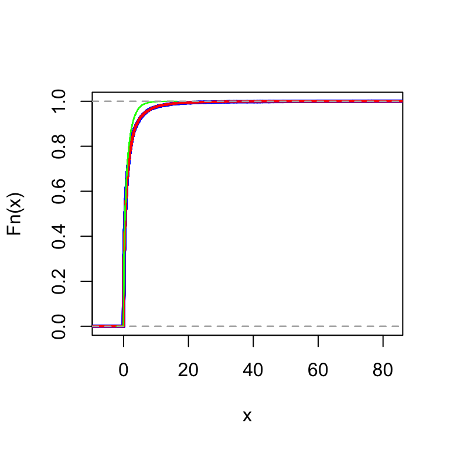

```r
plot(ecdf(rt(10000, df = 5)^2), col = "blue", lwd = 3, main = "")
plot(ecdf(rf(10000, df1 = 1, df2 = 5)), add = TRUE, col = "red", lwd = 2)
plot(ecdf(rchisq(10000, df = 1)), add = TRUE, col = "green", lwd = 1)
```

## \(t^2\), \(F\), and \(\chi^2\)

### Under certain conditions, these 3 distributions are the same:

- when \(F_{df1 = 1}\) & when `residuals.df` \(\rightarrow \infty\)

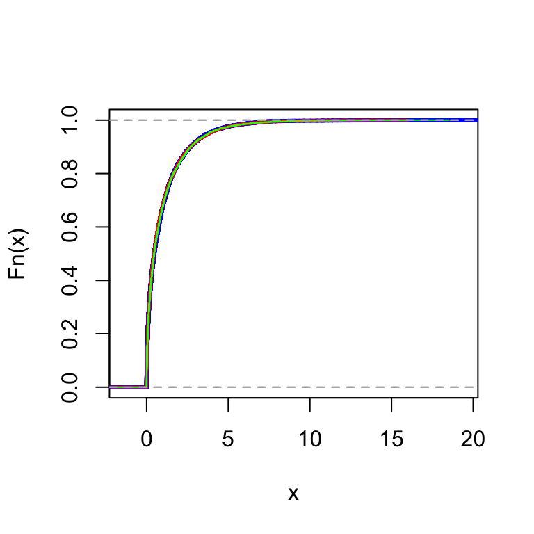

```r
plot(ecdf(rt(10000, df = 500)^2), col = "blue", lwd = 3, main = "")
plot(ecdf(rf(10000, df1 = 1, df2 = 500)), add = TRUE, col = "red", lwd = 2)
plot(ecdf(rchisq(10000, df = 1)), add = TRUE, col = "green", lwd = 1)
```

## Anova: Poisson and Binomial

### For poisson() and binomial(), better use the likelihood ratio test

```r
Anova(mod_poiss2, test = "LR")
```

```
## Analysis of Deviance Table (Type II tests)
##
## Response: eggs
##              LR Chisq Df Pr(>Chisq)
## humans_eaten  0.23473  1      0.628
```

```r
LR <- -2 * (logLik(update(mod_poiss2, . ~ 1)) - logLik(mod_poiss2))
pvalue <- 1 - pchisq(LR, 1)
cbind(LR, pvalue)
```

```
##            LR    pvalue
## [1,] 0.234734 0.6280356
```

## Comparing the robustness of tests using simulations

```r
set.seed(1L)
N <- 20
pv <- replicate(1000, {
  d <- data.frame(eggs = rpois(N, lambda = 0.5),
                  humans_eaten = round(runif(N, min = 0, max = 50)))
  mod_poiss_1      <- glm(eggs ~ humans_eaten, family = poisson(), data = d)
  mod_poiss_1_null <- glm(eggs ~ 1, family = poisson(), data = d)
  c(LR = anova(mod_poiss_1, mod_poiss_1_null, test = "LR")[2, "Pr(>Chi)"],
    z = summary(mod_poiss_1)$coefficients["humans_eaten", "Pr(>|z|)" ])
})
rbind(mean(pv["LR", ] <= 0.05, na.rm = TRUE), mean(pv["z", ] <= 0.05, na.rm = TRUE))
```

```
##       [,1]
## [1,] 0.058
## [2,] 0.038
```

## Comparing the robustness of tests using simulations

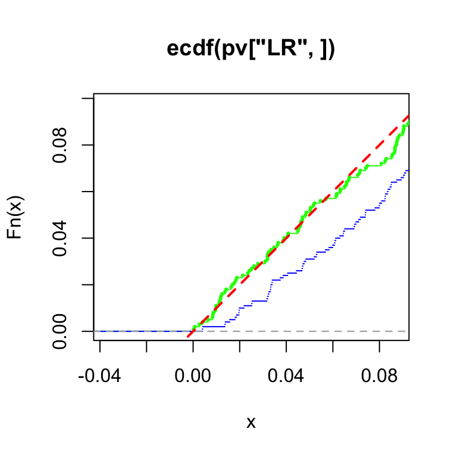

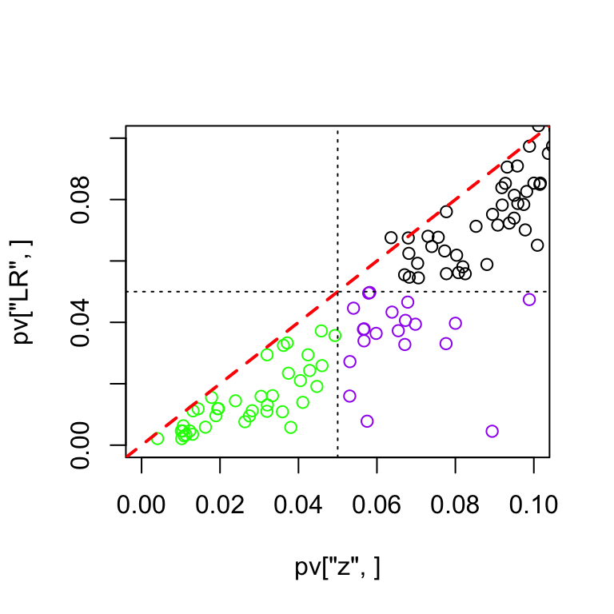

But the performances depend on the predictor(s), lambda and sample size…

## Comparing the robustness of tests using simulations

```r
set.seed(1L)
N <- 20
pv <- replicate(1000, {
  d <- data.frame(eggs = rpois(N, lambda = 0.5),
                  mood = factor(sample(c("depr.", "happy", "upset", "tired", "anxious"), size = N, replace = TRUE)))
  mod_poiss_1      <- glm(eggs ~ mood, family = poisson(), data = d)
  mod_poiss_1_null <- glm(eggs ~ 1, family = poisson(), data = d)
  c(LR = anova(mod_poiss_1, mod_poiss_1_null, test = "LR")[2, "Pr(>Chi)"],
    F = Anova(mod_poiss_1, test = "F")["mood", "Pr(>F)"])
})
rbind(mean(pv["LR", ] <= 0.05, na.rm = TRUE), mean(pv["F", ] <= 0.05, na.rm = TRUE))
```

```
##       [,1]
## [1,] 0.078
## [2,] 0.126
```

## Comparing the robustness of tests using simulations

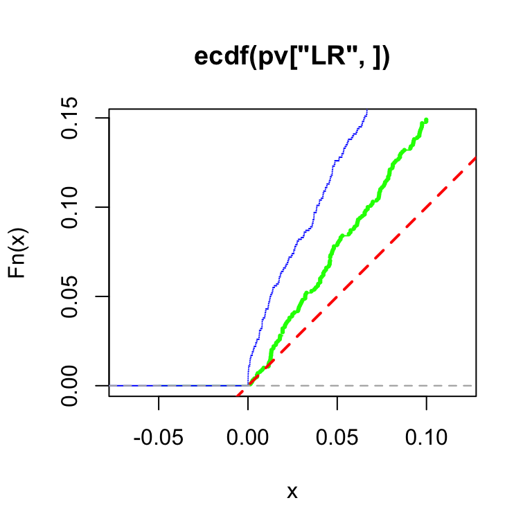

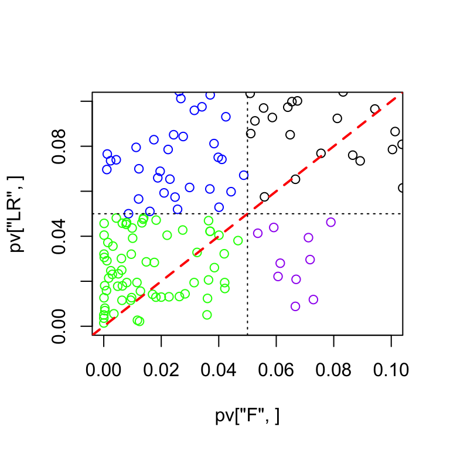

But the performances depend on the predictor(s), lambda and sample size…

## Anova: parametric bootstrap with `spaMM`

### It works for all!

```r
anova(mod_gauss2_spaMM, mod_gauss2_spaMM0, boot.repl = 200)
```

```
## Bootstrap replicates: bootstrap took 8.4 s.
```

```
##      chi2_LR df      p_value
## p_v 12.04748  1 0.0005186244
##  ======== Bootstrap: ========
## Raw simulated p-value: 0.00995
## Bartlett-corrected LR test:
##      chi2_LR df     p_value
## p_v 10.25416  1 0.001363767
```

## Anova: parametric bootstrap with `spaMM`

### It works for all!

```r
anova(mod_poiss2_spaMM, mod_poiss2_spaMM0, boot.repl = 200)
```

```
## Bootstrap replicates: bootstrap took 6.6 s.
```

```
##      chi2_LR df   p_value
## p_v 0.234734  1 0.6280356
##  ======== Bootstrap: ========
## Raw simulated p-value: 0.632
## Bartlett-corrected LR test:
##       chi2_LR df   p_value
## p_v 0.2212452  1 0.6380927
```

## Comparing tests using spaMM

```r
set.seed(1L)
N <- 20
pv <- replicate(200, {
  d <<- data.frame(eggs = rpois(N, lambda = 2),
                  humans_eaten = round(runif(N, min = 0, max = 50)))
  mod_poiss_1      <- glm(eggs ~ humans_eaten, family = poisson(), data = d)
  mod_poiss_1_null <- glm(eggs ~ 1, family = poisson(), data = d)
  mod_poiss_1_spaMM      <- fitme(eggs ~ humans_eaten, family = poisson(), data = d)
  mod_poiss_1_null_spaMM <- fitme(eggs ~ 1, family = poisson(), data = d)

  boot <- anova(mod_poiss_1_spaMM, mod_poiss_1_null_spaMM, boot.repl = 199, nb_cores = 4L)
  c(z = summary(mod_poiss_1)$coefficients["humans_eaten", "Pr(>|z|)" ],
    LR = boot$basicLRT$p_value,
    Bartlett = boot$BartBootLRT$p_value,
    Raw = boot$rawBootLRT$p_value)
})
```

[output not shown]

[output cut: 145 more lines]

[output not shown]

## Comparing tests using spaMM

```r
rbind(mean(pv["z", ] <= 0.05, na.rm = TRUE),
      mean(pv["LR", ] <= 0.05, na.rm = TRUE),
      mean(pv["Bartlett", ] <= 0.05, na.rm = TRUE),
      mean(pv["Raw", ] <= 0.05, na.rm = TRUE))
```

```
##       [,1]
## [1,] 0.044
## [2,] 0.046
## [3,] 0.050
## [4,] 0.047
```

Not bad!

## Comparing tests using spaMM

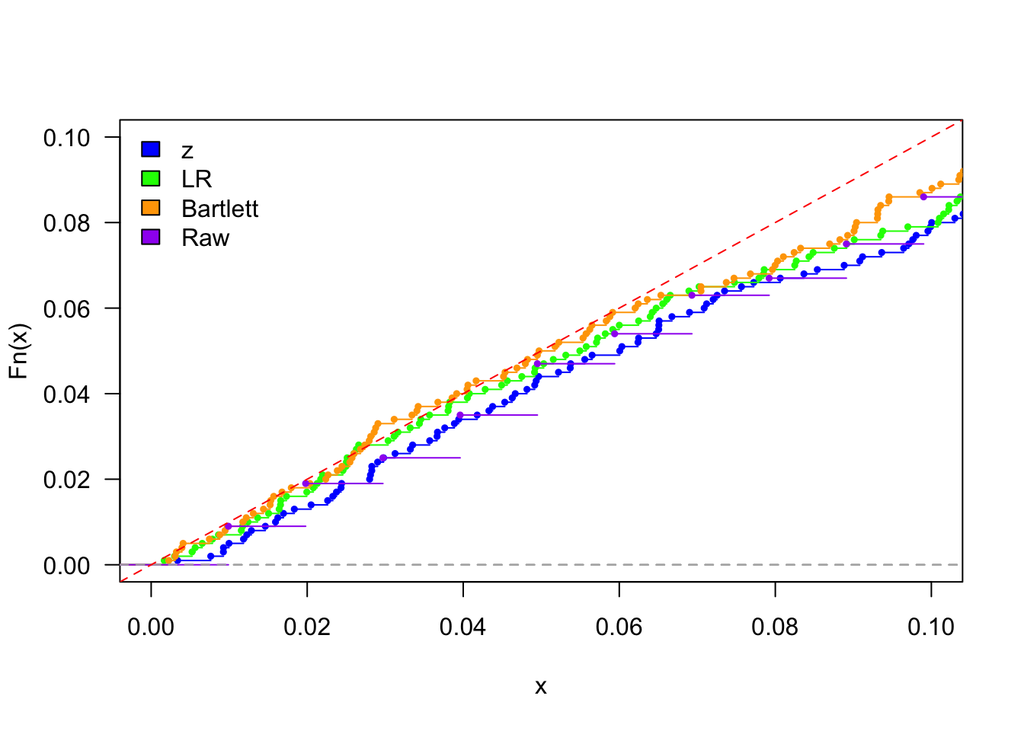

## Non-nested model comparison

## Comparing different links or different families

Since the response variable does not change but models are not nested, you can use:

- likelihood (larger = better)
- deviance (smaller = better)
- AIC (smaller = better)

For true test, the only method available is the parametric bootstrap!

Note: you cannot compare deviances between `gaussian()` and other families unless you use the scaled deviance for the `gaussian()`.

## Comparing LM vs GLM

### Responses differ, so only parametric bootstrap is possible

```r
set.seed(1L)
x <- seq(1, 2, length = 100)
y <- exp(rnorm(n = length(x), mean = 2 + 1 * x, sd = 0.5))

mod_lm   <- lm(log(y) ~ x)
mod_glm  <- glm(y ~ x, family = gaussian(link = "log"))
logLik_diff_H0 <- replicate(1000, {
  new.y <- exp(as.matrix(simulate(mod_lm)))
  logLik(lm(log(new.y) ~ x)) - logLik(glm(new.y ~ x, family = gaussian(link = "log")))
  })
logLik_diff_obs <- logLik(mod_lm) - logLik(mod_glm)
(sum(logLik_diff_obs < logLik_diff_H0) + 1) / (length(logLik_diff_H0) + 1)
```

```
## [1] 0.3656344
```

In principle, we could have do the opposite, but in practice the function `simulate()` bugs for GLM with `gaussian()$link != "identity"`.

## What you need to remember

- that estimates are still roughly normally distributed (but only roughly)
- how to compute intervals for GLM
- that intervals based on likelihood are best for family with known dispersion
- that established methods don't always work well, so you should always run tests
- that parametric bootstrap can outperform other methods when done properly
- that intervals on scale other than \(\eta\) must be done by hand or using `spaMM`
- that tests from summary tables are only reliable for the gaussian family
- that LR tests are best for family with known dispersion
- that LR tests by parametric bootstrap are best in all situations and easy to do with `spaMM`

## Table of contents

## The Generalized Linear Model: GLM

- 3.0 Introduction
- 3.1 Intervals & Tests
- 3.2 Residuals & Assumptions
- 3.3 Let's practice more